# RF_First_Eval

G7

2024-05-16

```r
packages <- c('tidyverse', 'rpart', 'rpart.plot', 'gtools', 'Rmisc', 'scales', 'viridis', 'caret', 'AMR', 'randomForest', 'fastDummies', 'rattle', 'xgboost', 'ggpubr', 'reshape2', 'mlbench', 'readxl', 'ranger', 'tidymodels', 'parallel', 'doParallel', 'ggpubr', 'caret')

suppressWarnings({
  if (sum(as.numeric(!packages %in% installed.packages())) != 0) {
    instalador <- packages[!packages %in% installed.packages()]
    for (i in 1:length(instalador)) {
      install.packages(instalador, dependencies = TRUE)
      break
    }
  }
  sapply(packages, require, character.only = TRUE)
})
```

```
##    tidyverse        rpart   rpart.plot       gtools        Rmisc       scales
##         TRUE         TRUE         TRUE         TRUE         TRUE         TRUE
##      viridis        caret          AMR randomForest  fastDummies       rattle
##         TRUE         TRUE         TRUE         TRUE         TRUE         TRUE
##      xgboost       ggpubr     reshape2      mlbench       readxl       ranger
##         TRUE         TRUE         TRUE         TRUE         TRUE         TRUE
##   tidymodels     parallel   doParallel       ggpubr        caret
##         TRUE         TRUE         TRUE         TRUE         TRUE
```

# Regression

## Preparing the data

```r
df <- read_excel("df_definitivo-2.xlsx", sheet = "Copia de datos")
rownames(df) = df$id
df$Afectacion_ganglionar = as.numeric(df$Afectacion_ganglionar)
df$Afectacion_metastasica = as.numeric(df$Afectacion_metastasica)
df$Tamaño_tumor = as.numeric(df$Tamaño_tumor)
df$Grado_tox = as.numeric(df$Grado_tox)
df$SII_pre = log(df$SII_pre)
df$SII_1C = log(df$SII_1C)
df$SII_2C = log(df$SII_2C)
df$SII_1eval = log(df$SII_1eval)

variables_inutiles = c("Anciano", "Peso", "Talla", "SG", "SG_cens", "SLP", "SLP_cens", "Tipo_tox", "NLR2C_corte4o5")

df2 = select(df, -all_of(variables_inutiles))
```

## VARIABLE SELECTION FOR FIRST EVALUATION

```r
X1.1 = df2[,2:49]
X1.2 = df2[,61:67]
X = bind_cols(X1.1, X1.2)
X = data.frame(scale(X, center = TRUE, scale = TRUE))
X$pri_eval_num_ok = df2$pri_eval_num_ok
```

## Model with no parameter setting-FIRST EVALUATION-

```r
# Model creation and training
# ==============================================================================
set.seed(123)
modelo  <- ranger(
            formula   = pri_eval_num_ok ~ .,
            data      = X,
            num.trees = 10,
            seed      = 123
           )

print(modelo)
```

```
## Ranger result
##
## Call:
##  ranger(formula = pri_eval_num_ok ~ ., data = X, num.trees = 10,      seed = 123)
##
## Type:                             Regression
## Number of trees:                  10
## Sample size:                      34
## Number of independent variables:  55
## Mtry:                             7
## Target node size:                 5
## Variable importance mode:         none
## Splitrule:                        variance
## OOB prediction error (MSE):       0.4134601
## R squared (OOB):                  0.1534632
```

```r
predict(modelo, X) %>% head
```

```
## $predictions
##  [1] 1.860000 1.300000 1.173333 1.800000 1.833333 1.400000 1.630000 1.380000
##  [9] 2.100000 1.480000 2.660000 1.980000 1.480000 2.260000 2.313333 1.373333
## [17] 1.913333 1.240000 1.183333 2.093333 2.580000 1.900000 1.355000 1.800000
## [25] 1.880000 2.833333 1.400000 2.880000 1.855000 1.840000 2.693333 1.033333
## [33] 1.280000 1.808333
##
## $num.trees
## [1] 10
##
## $num.independent.variables
## [1] 55
##
## $num.samples
## [1] 34
##
## $treetype
## [1] "Regression"
```

## Ealuating the model

```r
# Training data
p_train <- predict(modelo, X)

# Evaluation data frame (Training)
eval_train <- data.frame(obs=X$pri_eval_num_ok,
                         pred=p_train)
head(eval_train)
```

```
##   obs prediction
## 1   2   1.860000
## 2   1   1.300000
## 3   1   1.173333
## 4   2   1.800000
## 5   2   1.833333
## 6   1   1.400000
```

```r
predicciones <- p_train$predictions
```

```r
# Evaluation function
evaluate <- function(pred, obs) {
  mse <- mean((pred - obs)^2)
  rmse_ <- sqrt(mse)
  mae <- mean(abs(pred - obs))
  r_squared <- 1 - (sum((obs - pred)^2) / sum((obs - mean(obs))^2))

  cat("MSE:", mse, "\n")
  cat("RMSE:", rmse_, "\n")
  cat("MAE:", mae, "\n")
  cat("R-squared:", r_squared, "\n")
}

# Using the evaluation function
evaluate(predicciones, X$pri_eval_num_ok)
```

```
## MSE: 0.0727656
## RMSE: 0.269751
## MAE: 0.2381863
## R-squared: 0.8465018
```

## Hyperparameter setting

### Grid-search con LOO

```r
# DEFINITION OF THE MODEL AND THE HYPERPARAMETERS TO BE OPTIMIZED
# ==============================================================================
modelo <- rand_forest(
             mode  = "regression",
             mtry  = tune(),
             trees = tune()
          ) %>%
          set_engine(
            engine     = "ranger",
            max.depth  = tune(),
            importance = "none",
            seed       = 123
          )

# DEFINITION OF PREPROCESSING
# ==============================================================================
# In this case there is no preprocessing, so the transformer contains only the formula definition and the training data.
# the formula definition and the training data.
transformer <- recipe(
                  formula = pri_eval_num_ok ~ .,
                  data    =  X
               )

# DEFINITION OF THE VALIDATION STRATEGY AND CREATION OF PARTITIONS
# ==============================================================================
set.seed(1234)
cv_folds <- vfold_cv(
              data    = X,
              v       = nrow(X),
              repeats = 1,
              strata  = pri_eval_num_ok
            )

# WORKFLOW
# ==============================================================================
workflow_modelado <- workflow() %>%
                     add_recipe(transformer) %>%
                     add_model(modelo)


# GRID OF HIPERPARAMETERS
# ==============================================================================
hiperpar_grid <- expand_grid(
                  'trees'     = c(50, 100, 500, 1000, 5000),
                  'mtry'      = c(3, 5, 7, ncol(X)-1),
                  'max.depth' = c(1, 3, 10, 20)
                 )

# EXECUTION OF HYPERPARAMETER OPTIMIZATION #==============================================================================
cl <- makePSOCKcluster(parallel::detectCores() - 1)
registerDoParallel(cl)

grid_fit <- tune_grid(
              object    = workflow_modelado,
              resamples = cv_folds,
              metrics   = metric_set(rmse),
              grid      = hiperpar_grid
            )

stopCluster(cl)
```

```r
# Best hyperparameters by cross-validation #==============================================================================
show_best(grid_fit, metric = "rmse", n = 1)
```

```
## # A tibble: 1 × 9
##    mtry trees max.depth .metric .estimator  mean     n std_err .config
##   <dbl> <dbl>     <dbl> <chr>   <chr>      <dbl> <int>   <dbl> <chr>
## 1     5  1000        10 rmse    standard   0.524    16  0.0470 Preprocessor1_Mo…
```

### Training the model with the best hyperparameters

```r
# FINAL TRAINING
# =============================================================================
mejores_hiperpar <- select_best(grid_fit, metric = "rmse")

modelo_final_fit <- finalize_workflow(
                        x = workflow_modelado,
                        parameters = mejores_hiperpar
                    ) %>%
                    fit(
                      data = X
                    ) %>%
                    extract_fit_parsnip()
```

```r
# Final model training error
# ==============================================================================
predicciones <- modelo_final_fit %>%
                predict(
                  new_data = X,
                  type     = "numeric"
                )

predicciones <- predicciones %>%
                bind_cols(X %>% dplyr::select(pri_eval_num_ok))

rmse_test  <- rmse(
                 data     = predicciones,
                 truth    = pri_eval_num_ok,
                 estimate = .pred,
                 na_rm    = TRUE
              )
rmse_test
```

```
## # A tibble: 1 × 3
##   .metric .estimator .estimate
##   <chr>   <chr>          <dbl>
## 1 rmse    standard       0.264
```

## Importance of predictors

Importance by node purity

In the above models, the importance argument defaults to “none”. This disables the calculation of predictor importance to reduce training time. The model is trained again, with the best hyperparameters found, but this time with importance = “impurity”. The ranger models calculate impurity from the Gini index in classification problems and with the variance in regression.

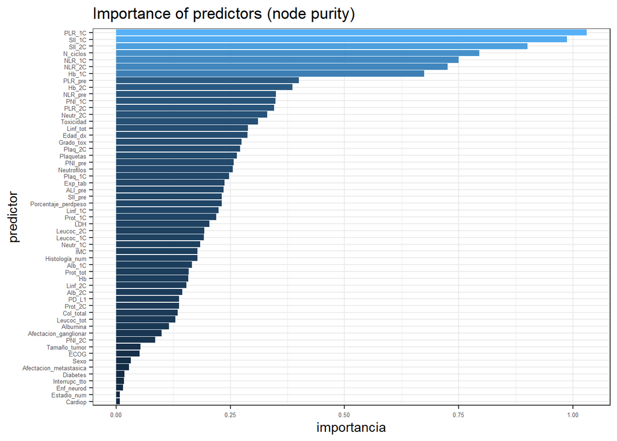

```r
# model training
modelo <- rand_forest(
             mode  = "regression"
          ) %>%
          set_engine(
            engine     = "ranger",
            importance = "impurity",
            seed       = 123
          )

modelo <- modelo %>% finalize_model(mejores_hiperpar)
modelo <- modelo %>% fit(pri_eval_num_ok ~., data = X)

# Importance
importancia_pred <- modelo$fit$variable.importance %>%
                    enframe(name = "predictor", value = "importancia")

# Graph
ggplot(
  data = importancia_pred,
  aes(x    = reorder(predictor, importancia),
      y    = importancia,
      fill = importancia)
) +
labs(x = "predictor", title = "Importance of predictors (node purity)") +
geom_col() +
coord_flip() +
theme_bw() +
theme(legend.position = "none",axis.text = element_text(size = 5))
```

## TOP 15

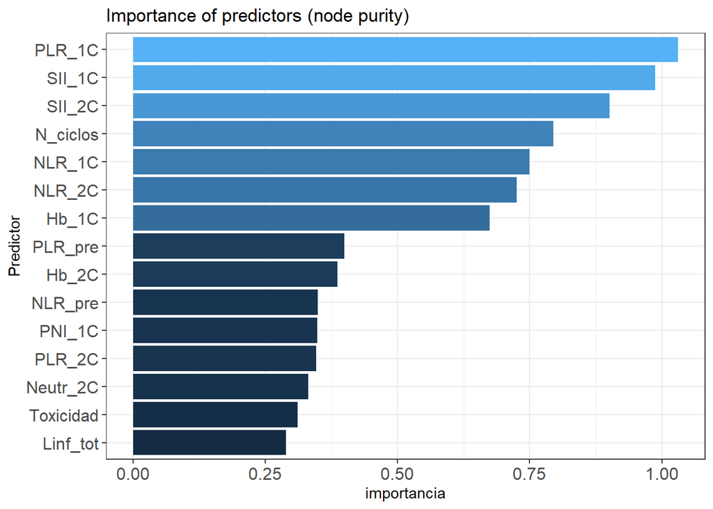

```r
# Filtering to keep only the 15 most important variables
importancia_pred_top15 <- importancia_pred %>%
                          arrange(desc(importancia)) %>%
                          top_n(15, importancia)

# Chart of the 15 most important variables
ggplot(
  data = importancia_pred_top15,
  aes(x    = reorder(predictor, importancia),
      y    = importancia,
      fill = importancia)
) +
labs(x = "Predictor", title = "Importance of predictors (node purity)") +
geom_col() +
coord_flip() +
theme_bw() +
theme(legend.position = "none", axis.text = element_text(size = 12))
```

## Importance by permutation

The model is trained again, with the best hyperparameters found, but this time indicating importance = “permutation”.

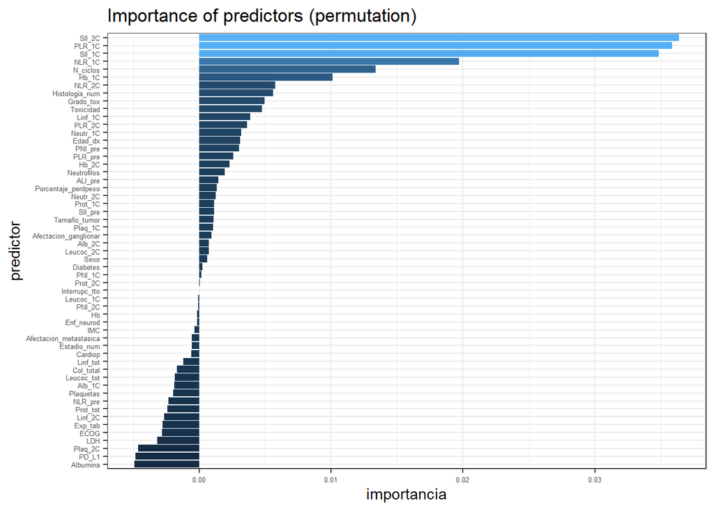

```r
modelo <- rand_forest(
             mode  = "regression"
          ) %>%
          set_engine(
            engine     = "ranger",
            importance = "permutation",
            seed       = 123
          )

modelo <- modelo %>% finalize_model(mejores_hiperpar)
modelo <- modelo %>% fit(pri_eval_num_ok ~., data = X)

importancia_pred <- modelo$fit$variable.importance %>%
                    enframe(name = "predictor", value = "importancia")

ggplot(
  data = importancia_pred,
  aes(x    = reorder(predictor, importancia),
      y    = importancia,
      fill = importancia)
) +
labs(x = "predictor", title = "Importance of predictors (permutation)") +
geom_col() +
coord_flip() +
theme_bw() +
theme(legend.position = "none",axis.text = element_text(size = 5))
```

## TOP 15

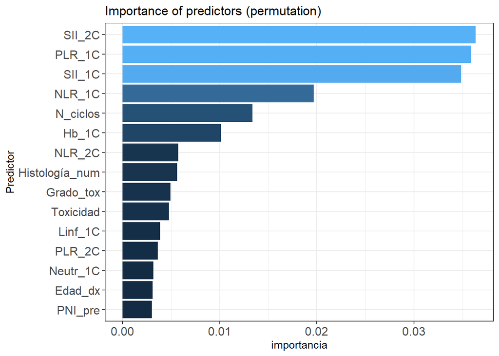

```r
importancia_pred_top15 <- importancia_pred %>%
                          arrange(desc(importancia)) %>%
                          slice_max(order_by = importancia, n = 15)

ggplot(
  data = importancia_pred_top15,
  aes(x    = reorder(predictor, importancia),
      y    = importancia,
      fill = importancia)
) +
labs(x = "Predictor", title = "Importance of predictors (permutation)") +
geom_col() +
coord_flip() +
theme_bw() +
theme(legend.position = "none", axis.text = element_text(size = 12))
```

# Classification

```r
# Remove all objects from the global environment and the console
rm(list = ls())
cat("\014")
```

## Preparing the data

```r
df <- read_excel("df_definitivo-2.xlsx", sheet = "Copia de datos")
rownames(df) = df$id
df$Afectacion_ganglionar = as.numeric(df$Afectacion_ganglionar)
df$Afectacion_metastasica = as.numeric(df$Afectacion_metastasica)
df$Tamaño_tumor = as.numeric(df$Tamaño_tumor)
df$Grado_tox = as.numeric(df$Grado_tox)
df$SII_pre = log(df$SII_pre)
df$SII_1C = log(df$SII_1C)
df$SII_2C = log(df$SII_2C)
df$SII_1eval = log(df$SII_1eval)

variables_inutiles = c("Anciano", "Peso", "Talla", "SG", "SG_cens", "SLP", "SLP_cens", "Tipo_tox", "NLR2C_corte4o5")

df2 = select(df, -all_of(variables_inutiles))
```

## VARIABLE SELECTION FOR FIRST EVALUATION

```r
X1.1 = df2[,2:49]
X1.2 = df2[,61:67]
X2 = bind_cols(X1.1, X1.2)
X2 = data.frame(scale(X2, center = TRUE, scale = TRUE))
X2$pri_eval_num_ok <- as.factor(df2$pri_eval_num_ok)
```

## Model without hyperparameters

```r
set.seed(123)
modelo_sin_ajustar  <- ranger(
            formula   = pri_eval_num_ok ~ .,
            data      = X2,
            num.trees = 10,
            seed      = 123
           )

print(modelo_sin_ajustar)
```

```
## Ranger result
##
## Call:
##  ranger(formula = pri_eval_num_ok ~ ., data = X2, num.trees = 10,      seed = 123)
##
## Type:                             Classification
## Number of trees:                  10
## Sample size:                      34
## Number of independent variables:  55
## Mtry:                             7
## Target node size:                 1
## Variable importance mode:         none
## Splitrule:                        gini
## OOB prediction error:             64.71 %
```

```r
predict(modelo_sin_ajustar, X2) %>% head
```

```
## $predictions
##  [1] 2 1 1 2 2 1 2 1 2 1 3 2 1 2 2 1 2 1 1 2 3 2 1 2 2 3 2 3 2 2 3 1 1 2
## Levels: 1 2 3
##
## $num.trees
## [1] 10
##
## $num.independent.variables
## [1] 55
##
## $num.samples
## [1] 34
##
## $treetype
## [1] "Classification"
```

## Ealuating the model

```r
# Training data
p_train <- predict(modelo_sin_ajustar, X2)

# Evaluation data frame (Training)
eval_train <- data.frame(obs=X2$pri_eval_num_ok,
                         pred=p_train)
head(eval_train)
```

```
##   obs prediction
## 1   2          2
## 2   1          1
## 3   1          1
## 4   2          2
## 5   2          2
## 6   1          1
```

```r
predicciones_ <- p_train$predictions
```

```r
predictions <- predict(modelo_sin_ajustar, X2, type = "response")

predicciones_ <- predictions$predictions

eval_train <- data.frame(
  obs = X2$pri_eval_num_ok,
  pred = as.factor(predicciones_)
)

conf_matrix <- confusionMatrix(eval_train$pred, eval_train$obs)
print(conf_matrix)
```

```
## Confusion Matrix and Statistics
##
##           Reference
## Prediction  1  2  3
##          1 12  0  0
##          2  1 16  0
##          3  0  0  5
##
## Overall Statistics
##
##                Accuracy : 0.9706
##                  95% CI : (0.8467, 0.9993)
##     No Information Rate : 0.4706
##     P-Value [Acc > NIR] : 2.908e-10
##
##                   Kappa : 0.9516
##
##  Mcnemar's Test P-Value : NA
##
## Statistics by Class:
##
##                      Class: 1 Class: 2 Class: 3
## Sensitivity            0.9231   1.0000   1.0000
## Specificity            1.0000   0.9444   1.0000
## Pos Pred Value         1.0000   0.9412   1.0000
## Neg Pred Value         0.9545   1.0000   1.0000
## Prevalence             0.3824   0.4706   0.1471
## Detection Rate         0.3529   0.4706   0.1471
## Detection Prevalence   0.3529   0.5000   0.1471
## Balanced Accuracy      0.9615   0.9722   1.0000
```

## Improvement of hyperparameters

```r
modelo <- rand_forest(
             mode  = "classification",
             mtry  = tune(),
             trees = tune()
          ) %>%
          set_engine(
            engine     = "ranger",
            max.depth  = tune(),
            importance = "none",
            seed       = 123
          )

transformer <- recipe(
                  formula = pri_eval_num_ok ~ .,
                  data    =  X2
               )

set.seed(1234)
cv_folds <- vfold_cv(
              data    = X2,
              v       = nrow(X2),
              repeats = 1,
              strata  = pri_eval_num_ok
            )

workflow_modelado <- workflow() %>%
                     add_recipe(transformer) %>%
                     add_model(modelo)


hiperpar_grid <- expand_grid(
                  'trees'     = c(50, 100, 500, 1000, 5000),
                  'mtry'      = c(3, 5, 7, ncol(X2)-1),
                  'max.depth' = c(1, 3, 10, 20)
                 )

cl <- makePSOCKcluster(parallel::detectCores() - 1)
registerDoParallel(cl)

grid_fit <- tune_grid(
              object    = workflow_modelado,
              resamples = cv_folds,
              metrics   = metric_set(f_meas),
              grid      = hiperpar_grid
            )

stopCluster(cl)
```

```r
show_best(grid_fit, metric = "f_meas", n = 1)
```

```
## # A tibble: 1 × 9
##    mtry trees max.depth .metric .estimator  mean     n std_err .config
##   <dbl> <dbl>     <dbl> <chr>   <chr>      <dbl> <int>   <dbl> <chr>
## 1     3    50        10 f_meas  macro      0.711    15  0.0680 Preprocessor1_Mo…
```

```r
mejores_hiperpar <- select_best(grid_fit, metric = "f_meas")

modelo_final_fit <- finalize_workflow(
                        x = workflow_modelado,
                        parameters = mejores_hiperpar
                    ) %>%
                    fit(
                      data = X2
                    ) %>%
                   extract_fit_parsnip
```

```r
predicciones <- modelo_final_fit %>%
                predict(new_data = X2)

predicciones <- predicciones %>%
                bind_cols(X2 %>% dplyr::select(pri_eval_num_ok))

accuracy_test  <- accuracy(
                     data     = predicciones,
                     truth    = pri_eval_num_ok,
                     estimate = .pred_class,
                     na_rm    = TRUE
                  )
accuracy_test
```

```
## # A tibble: 1 × 3
##   .metric  .estimator .estimate
##   <chr>    <chr>          <dbl>
## 1 accuracy multiclass         1
```

```r
mat_confusion <- predicciones %>%
                 conf_mat(
                   truth     = pri_eval_num_ok,
                   estimate  = .pred_class
                 )
mat_confusion
```

```
##           Truth
## Prediction  1  2  3
##          1 13  0  0
##          2  0 16  0
##          3  0  0  5
```

## Probability prediction

Most Random Forest implementations, including ranger, allow predicting probabilities when dealing with classification problems. It is important to understand how these values are calculated in order to interpret and use them correctly.

```r
predicciones <- modelo_final_fit %>%
                predict(new_data = X2, type = "prob")
head(predicciones, 4)
```

```
## # A tibble: 4 × 3
##   .pred_1 .pred_2 .pred_3
##     <dbl>   <dbl>   <dbl>
## 1   0.321   0.660  0.0192
## 2   0.529   0.359  0.112
## 3   0.613   0.368  0.0187
## 4   0.194   0.738  0.0674
```

By default, predict() assigns each new observation to the class with the highest probability (in case of a tie it is assigned randomly). However, this need not be the desired behavior in all cases.

## Importance of predictors

Importance by node purity

In the above models, the importance argument defaults to “none”. This disables the calculation of predictor importance to reduce training time. The model is trained again, with the best hyperparameters found, but this time with importance = “impurity”. The ranger models calculate impurity from the Gini index in classification problems and with the variance in regression.

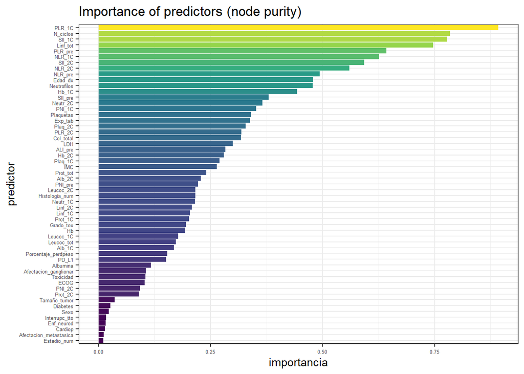

```r
modelo <- rand_forest(
             mode  = "classification"
          ) %>%
          set_engine(
            engine     = "ranger",
            importance = "impurity",
            seed       = 123
          )

modelo <- modelo %>% finalize_model(mejores_hiperpar)
modelo <- modelo %>% fit(pri_eval_num_ok ~., data = X2)

# Importancia
importancia_pred <- modelo$fit$variable.importance %>%
                    enframe(name = "predictor", value = "importancia")

# Gráfico
ggplot(
  data = importancia_pred,
  aes(x    = reorder(predictor, importancia),
      y    = importancia,
      fill = importancia)
) +
labs(x = "predictor", title = "Importance of predictors (node purity)") +
geom_col() +
scale_fill_viridis_c() +
coord_flip() +
theme_bw() +
theme(legend.position = "none", axis.text = element_text(size = 5))
```

## TOP 15

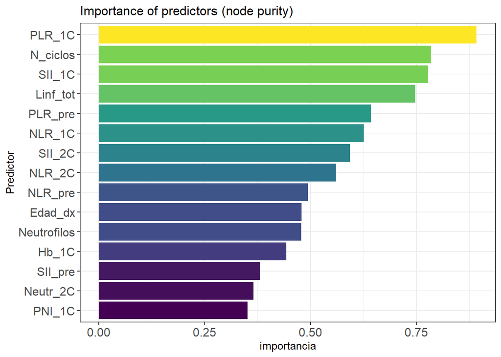

```r
importancia_pred_top15 <- importancia_pred %>%
                          arrange(desc(importancia)) %>%
                          top_n(15, importancia)

ggplot(
  data = importancia_pred_top15,
  aes(x    = reorder(predictor, importancia),
      y    = importancia,
      fill = importancia)
) +
labs(x = "Predictor", title = "Importance of predictors (node purity)") +
geom_col() +
scale_fill_viridis_c() +
coord_flip() +
theme_bw() +
theme(legend.position = "none", axis.text = element_text(size = 12))
```

## Importance by permutation

The model is trained again, with the best hyperparameters found, but this time indicating importance = “permutation”.

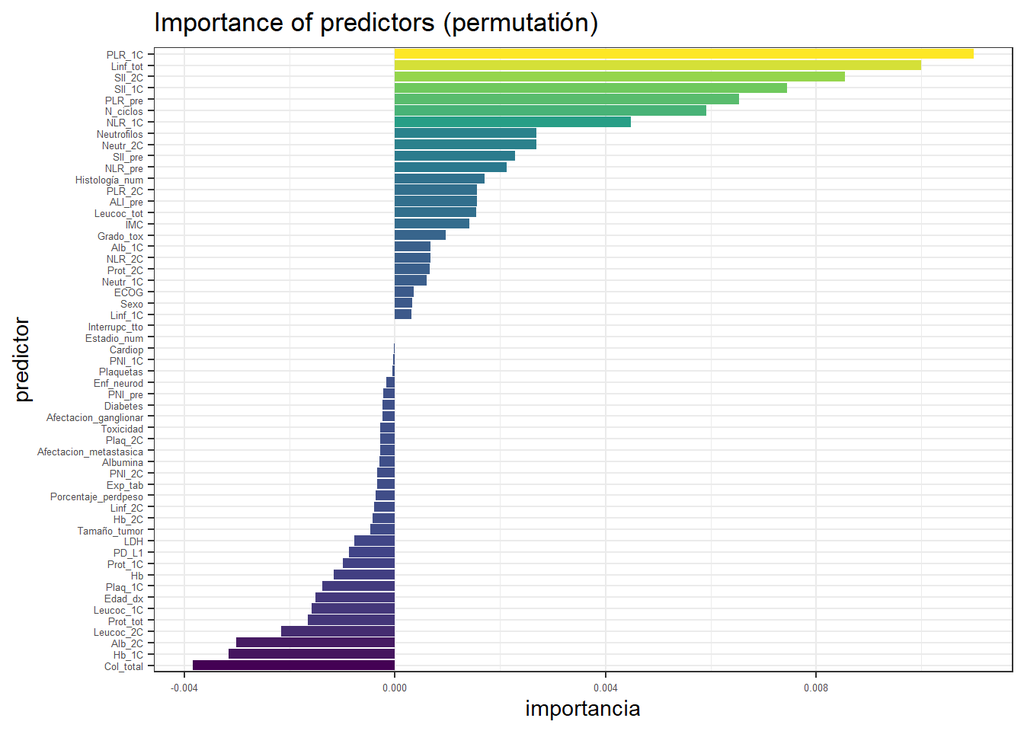

```r
# Entrenamiento modelo
modelo <- rand_forest(
             mode  = "classification"
          ) %>%
          set_engine(
            engine     = "ranger",
            importance = "permutation",
            seed       = 123
          )

modelo <- modelo %>% finalize_model(mejores_hiperpar)
modelo <- modelo %>% fit(pri_eval_num_ok ~., data = X2)

# Importancia
importancia_pred <- modelo$fit$variable.importance %>%
                    enframe(name = "predictor", value = "importancia")

# Gráfico
ggplot(
  data = importancia_pred,
  aes(x    = reorder(predictor, importancia),
      y    = importancia,
      fill = importancia)
) +
labs(x = "predictor", title = "Importance of predictors (permutatión)") +
geom_col() +
scale_fill_viridis_c() +
coord_flip() +
theme_bw() +
theme(legend.position = "none", axis.text = element_text(size = 5))
```

## Top 15

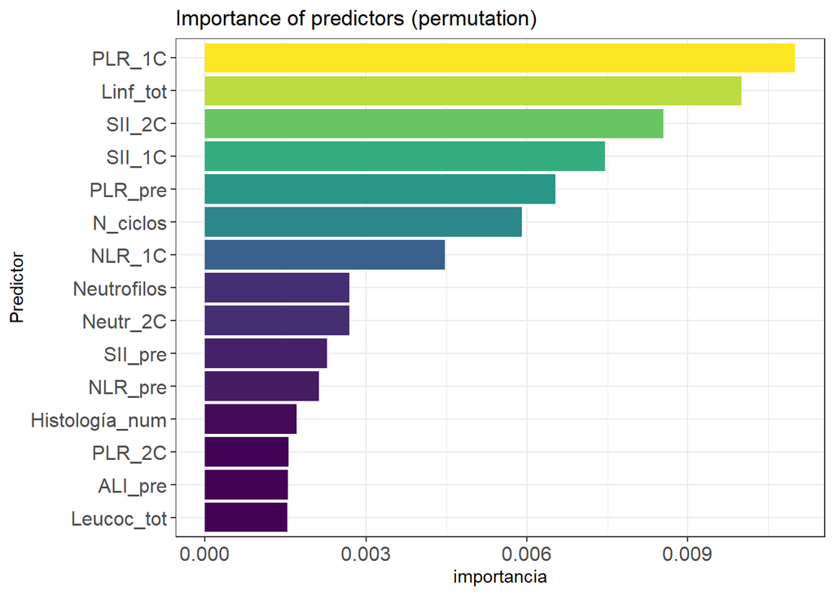

```r
importancia_pred_top15 <- importancia_pred %>%
                          arrange(desc(importancia)) %>%
                          top_n(15, importancia)

ggplot(
  data = importancia_pred_top15,
  aes(x    = reorder(predictor, importancia),
      y    = importancia,
      fill = importancia)
) +
labs(x = "Predictor", title = "Importance of predictors (permutation)") +
geom_col() +
scale_fill_viridis_c() +
coord_flip() +
theme_bw() +
theme(legend.position = "none", axis.text = element_text(size = 12))
```

Both strategies identify SII_2C, PLR_1C, SII_1C, NLR_1C, PLR_pre, N_cycles and Lymph_tot as the most influential predictors, according to the training data.